# Wedge Remodel Regression

John Chandler

# Measuring Remodel Impact

The Wedge did a remodel during most of 2016 that was disruptive. Sections were closed, moved around, and construction work limited access during most of the year. The official start date for the construction was 2016-02-01 and the official finish was 2016-11-01, though there is bleed over on each side.

In this notebook we’ll try to estimate the impact of that closure on overall store sales. Here are the main thigns we’ll work on in this notebook:

1. Building a basic time-series regression.
2. Practicing `dplyr`.
3. Connecting R to a SQL database.

## Gathering the Data

You’ve seen `dplyr` in our lectures. One great thing about `dplyr` is that it gives you access to databases through its companion package `dbplyr`. SQLite connectivity comes along automatically.

(One side note about databases, which I’ll try to remember to mention every time we talk about them. SQLite is a great database package for ease of use for moderately sized databases. If every table is under 5 GB and the entire database is under about 50 GB, then SQLite can be a good choice. If you’ve got more data than that, I recommend Postgres DBs. Those are the only two you really need to know, unless you’re in a Microsoft shop in which case you’ll use MS SQL Server–a great, albeit expensive, product.)

Let’s start by declaring some constants and creating a connection to your DB. These constants are for my  
machine, so you’ll need to *change this next code chunk* on your machine.

```r
db.location <- "C:/Users/jchan/Dropbox/Teaching/CorporatePartners/Wedge/DB/"
db.name <- "20160206_general.db"
con <- dbConnect(RSQLite::SQLite(),
                 dbname = paste0(db.location,db.name))
```

Let’s take a look at the tables in the DB, just to make sure everything looks as we expect:

```r
dbListTables(con)
```

```
## [1] "date_hour"               "departments"
## [3] "owner_month_dept"        "owner_products"
## [5] "owner_spend_date"        "owners"
## [7] "product_year_month_2014" "product_year_month_2015"
```

In my case the table `date_hour` holds the sales by date and hour. I’ll pull that information out of the DB using a command that looks a *lot* like dplyr, because it basically is.

```r
date_hour_db <- tbl(con, "date_hour")

d_db <- date_hour_db %>%
  group_by(date) %>%
  summarize(spend = sum(spend)) %>%
  arrange(date)

head(d_db)
```

```
## # Source:     lazy query [?? x 2]
## # Database:   sqlite 3.19.3
## #   [C:\Users\jchan\Dropbox\Teaching\CorporatePartners\Wedge\DB\20160206_general.db]
## # Ordered by: date
##         date    spend
##        <chr>    <dbl>
## 1 2010-01-01 37231.11
## 2 2010-01-02 71577.26
## 3 2010-01-03 78655.51
## 4 2010-01-04 65704.99
## 5 2010-01-05 62290.09
## 6 2010-01-06 62492.29
```

```r
d_db %>% show_query()
```

```
## <SQL>
## SELECT `date`, SUM(`spend`) AS `spend`
## FROM `date_hour`
## GROUP BY `date`
## ORDER BY `date`
```

The way to get the data out of the database is to use `collect`.

```r
d <- d_db %>% collect()
```

## Exploratory Data Analysis

Let’s start by adding some columns to the data that we’ll need later and calling `describe`.

```r
d <- d %>%
  mutate(year = year(date),
         month = str_pad(month(date),2,pad="0"),
         ym = paste(year,month,sep="-"))

Hmisc::describe(d)
```

```
## d
##
##  5  Variables      2579  Observations
## ---------------------------------------------------------------------------
## date
##        n  missing distinct
##     2579        0     2579
##
## lowest : 2010-01-01 2010-01-02 2010-01-03 2010-01-04 2010-01-05
## highest: 2017-01-27 2017-01-28 2017-01-29 2017-01-30 2017-01-31
## ---------------------------------------------------------------------------
## spend
##        n  missing distinct     Info     Mean      Gmd      .05      .10
##     2579        0     2579        1    73965    17136    54546    57828
##      .25      .50      .75      .90      .95
##    62973    70462    83065    97128   104256
##
## lowest :   3866.16   4973.46  22362.08  25165.17  26235.52
## highest: 129604.21 129630.17 134953.61 139806.40 139890.49
## ---------------------------------------------------------------------------
## year
##        n  missing distinct     Info     Mean      Gmd
##     2579        0        8     0.98     2013    2.328
##
## Value       2010  2011  2012  2013  2014  2015  2016  2017
## Frequency    364   364   365   362   364   364   365    31
## Proportion 0.141 0.141 0.142 0.140 0.141 0.141 0.142 0.012
## ---------------------------------------------------------------------------
## month
##        n  missing distinct
##     2579        0       12
##
## Value          1     2     3     4     5     6     7     8     9    10
## Frequency    248   198   217   210   217   208   217   217   210   217
## Proportion 0.096 0.077 0.084 0.081 0.084 0.081 0.084 0.084 0.081 0.084
##
## Value         11    12
## Frequency    210   210
## Proportion 0.081 0.081
## ---------------------------------------------------------------------------
## ym
##        n  missing distinct
##     2579        0       85
##
## lowest : 2010-01 2010-02 2010-03 2010-04 2010-05
## highest: 2016-09 2016-10 2016-11 2016-12 2017-01
## ---------------------------------------------------------------------------
```

Maybe it’d be nice to have a couple of plots. I’ll do a violinplot of sales by year and a time-series plot. This is all in `ggplot`.

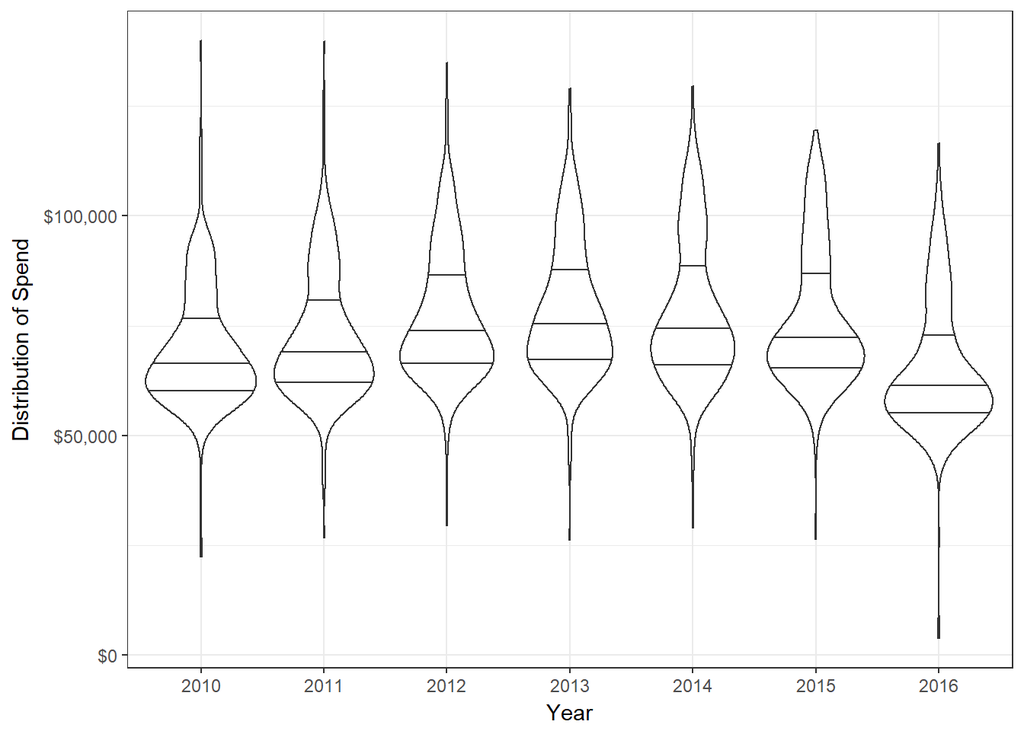

```r
ggplot(d %>% filter(year != 2017), # not enough data in 2017 to include
       aes(x=as.factor(year),y=spend)) +
  theme_bw() +
  labs(x="Year",y="Distribution of Spend") +
  geom_violin(draw_quantiles = c(0.25,0.5,0.75)) +
  scale_y_continuous(label=dollar)
```

From this it appears that 2016 was, indeed, a down year. Let’s do a time-series plot.

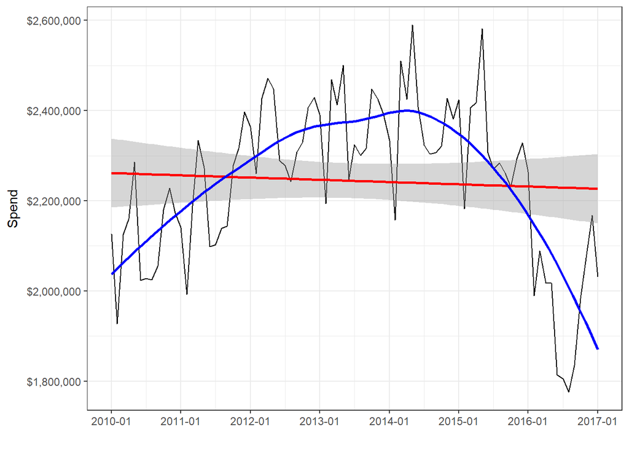

```r
for.plot <- d %>%
  group_by(ym) %>% #collapse to ym level
  summarize(spend=sum(spend))

# Getting the axes right is a hassle here
break.locations <- seq(1,85,by=12)
x.axis.labels <- for.plot$ym[break.locations]

ggplot(for.plot,
       aes(x=seq_along(ym),y=spend,group=1)) +
  theme_bw() +
  labs(x="",y="Spend") +
  geom_line() +
  stat_smooth(method="lm",col="red",se=T) +
  stat_smooth(col="blue",se=F) +
  scale_y_continuous(label=dollar) +
  scale_x_continuous(breaks=break.locations,
                     labels=x.axis.labels)
```

What do we notice? First, there’s not a big overall trend in the data–the red line is basically flat. The blue line tells the tale. Sales were growing till late 2012, then flattened off for a while, and then show a sharp drop off in 2016. Let’s try to measure that impact.

## Building a Model

To build a model, we’ll use daily sales and build a model that has terms for year, month, day of week and an indicator variable for the construction. We’ll use dummy variables for all of these, so that R doesn’t try to treat months as numeric data. Sometimes that’s not a problem, but December isn’t 12 times greater than January in any meaningful sense.

Let’s build a modeling data set.

```r
md <- d %>%
  select(date, spend) %>%
  mutate(date = ymd(date)) # convert to date

md <- md %>%
  mutate(year=factor(year(date)),
         month=factor(month(date)),
         dow = factor(wday(date,label=T),
                         ordered=F))
# dropping the ordering on dow. Ask me about this

# Let's make Monday the base factor for dow
md <- md %>%
  mutate(dow = relevel(dow,ref="Mon"))

# Adding in the indicator for remodel
remodel_time <- interval("2016-02-01",
                         "2016-11-01")
#uses great interval function from lubridate

md$remodel <- 0
md$remodel[md$date %within% remodel_time] <- 1


md %>% sample_n(10)
```

```
## # A tibble: 10 x 6
##          date     spend   year  month    dow remodel
##        <date>     <dbl> <fctr> <fctr> <fctr>   <dbl>
##  1 2012-03-25 100345.42   2012      3    Sun       0
##  2 2014-08-13  59641.28   2014      8    Wed       0
##  3 2016-06-15  58263.55   2016      6    Wed       1
##  4 2016-05-13  56416.61   2016      5    Fri       1
##  5 2012-08-31  81456.69   2012      8    Fri       0
##  6 2015-01-27  63354.00   2015      1   Tues       0
##  7 2012-12-14  85464.97   2012     12    Fri       0
##  8 2012-07-15  84209.84   2012      7    Sun       0
##  9 2011-03-12  85546.98   2011      3    Sat       0
## 10 2016-02-16  61172.53   2016      2   Tues       1
```

And now we’ll build a relatively straightfoward linear regression model.

```r
lm.1 <- lm(spend ~ year + month + dow + remodel,
           data=md)

summary(lm.1)
```

```
##
## Call:
## lm(formula = spend ~ year + month + dow + remodel, data = md)
##
## Residuals:
##    Min     1Q Median     3Q    Max
## -65063  -4286   -312   3867  77167
##
## Coefficients:
##             Estimate Std. Error t value Pr(>|t|)
## (Intercept)  65765.0      932.1  70.556  < 2e-16 ***
## year2011      2887.8      708.9   4.074 4.77e-05 ***
## year2012      7666.7      708.4  10.823  < 2e-16 ***
## year2013      8932.8      709.9  12.584  < 2e-16 ***
## year2014      8597.0      708.9  12.128  < 2e-16 ***
## year2015      7249.8      708.9  10.227  < 2e-16 ***
## year2016       685.7     1180.2   0.581 0.561291
## year2017     -3233.3     1898.8  -1.703 0.088732 .
## month2        1633.3      957.0   1.707 0.087990 .
## month3        2029.1      935.4   2.169 0.030153 *
## month4        4700.6      942.9   4.985 6.60e-07 ***
## month5        4082.1      935.4   4.364 1.33e-05 ***
## month6         535.8      945.2   0.567 0.570881
## month7       -3002.2      935.4  -3.210 0.001346 **
## month8       -3313.3      935.4  -3.542 0.000404 ***
## month9        -103.5      942.9  -0.110 0.912622
## month10       -158.2      935.4  -0.169 0.865727
## month11       3344.4      925.8   3.613 0.000309 ***
## month12       4028.7      925.8   4.352 1.40e-05 ***
## dowSun       21523.8      704.6  30.549  < 2e-16 ***
## dowTues      -6385.5      703.6  -9.076  < 2e-16 ***
## dowWed       -6869.6      704.1  -9.757  < 2e-16 ***
## dowThurs     -7559.9      704.1 -10.737  < 2e-16 ***
## dowFri        1069.3      703.6   1.520 0.128732
## dowSat       17631.1      704.1  25.040  < 2e-16 ***
## remodel      -6688.5     1253.1  -5.338 1.02e-07 ***
## ---
## Signif. codes:  0 '***' 0.001 '**' 0.01 '*' 0.05 '.' 0.1 ' ' 1
##
## Residual standard error: 9563 on 2553 degrees of freedom
## Multiple R-squared:  0.6305, Adjusted R-squared:  0.6269
## F-statistic: 174.2 on 25 and 2553 DF,  p-value: < 2.2e-16
```

```r
anova(lm.1)
```

```
## Analysis of Variance Table
##
## Response: spend
##             Df     Sum Sq    Mean Sq F value    Pr(>F)
## year         7 5.8870e+10 8.4100e+09  91.960 < 2.2e-16 ***
## month       11 1.8227e+10 1.6570e+09  18.118 < 2.2e-16 ***
## dow          6 3.1867e+11 5.3112e+10 580.759 < 2.2e-16 ***
## remodel      1 2.6055e+09 2.6055e+09  28.490 1.025e-07 ***
## Residuals 2553 2.3348e+11 9.1453e+07
## ---
## Signif. codes:  0 '***' 0.001 '**' 0.01 '*' 0.05 '.' 0.1 ' ' 1
```

Let’s discuss the interpretation of this together.

## Measuring Impact

One quick way to measure impact: we can take the coefficient of remodel and multiply by the number of 1s we have in that column from modeling.

```r
remodel.coef <- coef(lm.1)[names(coef(lm.1))=="remodel"]
remodel.coef * sum(md$remodel)
```

```
##  remodel
## -1839324
```

When I ran this I had an impact of $1.8M. That’s a lot.

Another way to estimate the impact is to create a counter-factual data set that has remodel set to zero everywhere. Then you can use `predict` to pass in the new data and to get projections.

## Cleaning up

When you’re done, close your DB connection.

```r
dbDisconnect(con)
```